# Evolutionary rescue with migration: a sea turtle case study

# Model question and assumptions

Our model explores how immigration from a source beach affects the population of non-adapted and adapted sea turtles on a local beach exposed to environmental warming. We compare the two turtle types over several generations and investigate how different immigration rates influence population size, persistence and the establishment of the adapted type.

The model represents two conceptual populations: a local population on a beach affected by warming and a source population on a cooler, more favourable beach but also affected by warming or overpopulation. Only the local population is simulated dynamically. The source population is assumed to remain constant and continuously supplies immigrants to the local population.

The local population consists of two types:

*Type a (non-adapted turtles):* These represent turtles arriving from the cooler source beach as well as individuals already living on the local beach. Their expected offspring production is reduced by the warming-related decline rate (`decay_rate`). *Type A (adapted turtles):* These represent turtles that are better adapted to the environmental conditions of the warmer local beach. Their expected reproductive output is affected by warming but also benefits from a relative reproductive advantage specified by `sel_coeff`.

New type-*A* individuals can arise through mutations from type *a*, with the probability of mutation determined by `mut_rate`.

In the current model, all immigrants arriving from the source population belong to type *a*, not type *A*. This means that immigration increases the number of non-adapted individuals in the local population. The source population does not lose individuals when it sends immigrants, and immigration occurs in one direction only, from the cooler source beach to the warmer local beach.

The model is a simplified representation of these processes. The parameter `decay_rate` represents the negative effect of warming on reproductive output rather than simulating changes in ocean or sand temperature directly. Similarly, `sel_coeff` represents the relative reproductive advantage of the adapted type under the new environmental conditions. Type *A* is an abstract model type and does not represent a known mutation or a measured genetic variant in sea turtles.

Migration is represented by an immigration rate rather than by explicitly modelling different migration routes, movement between habitats or route-specific mortality. Therefore, the model focuses on how the arrival of non-adapted individuals influences the persistence of the local population and the spread of the adapted type.

# Parameters, initial conditions and variables

# Simulate One Generation

The first function calculates what happens over one generation. The order of events in our code is:

1. Generate offspring for both types.
2. If the total offspring exceeds carrying capacity, reduce the offspring numbers to the limit.
3. Generate mutations from type `a` to type `A` among the `a` offspring.
4. Generate immigrants of type `a` from the source beach.
5. Calculate the population sizes `a` and `A` for the next generation.

```r
# FUNCTION 1: SIMULATE ONE GENERATION

# The model includes two turtle types:
# a = usual turtles, which are affected by warming
# A = adapted turtles, which have a relative growth advantage

simulate_one_gen <- function(N_a, N_A, decay_rate, sel_coeff, mut_rate, mig_rate, N_source_a, carrying_capacity = 1000) {

# STEP 1: Generate offspring for each turtle type

# For type a, the expected number of offspring is reduced
# by the warming-related decay rate.
# For type A, offspring production depends on its current population, its selection advantage, warming and how close the total population is to carrying capacity.
  offsp_a <- rpois(1, N_a * (1 - decay_rate))
  offsp_A <- rpois(1, N_A + N_A * (sel_coeff - decay_rate) * (1 - (N_a + N_A) / carrying_capacity))

# Calculate the total number of offspring of both types.
  offsp_total <- offsp_A + offsp_a

# If the total exceeds carrying capacity, randomly retain individuals until the population is within the limit.
  if (offsp_total > carrying_capacity)
    {

    offsp_a <- rbinom(1, carrying_capacity, offsp_a / offsp_total)

# The remaining individuals belong to type A.
    offsp_A <- carrying_capacity - offsp_a
  }

# STEP 2: Simulate mutation from type a to type A

# The expected number of mutations depends on the number of type-a offspring and the mutation rate.
  mut_a_to_A <- rpois(1, offsp_a * mut_rate)

# STEP 3: Simulate immigration from the source beach

# The number of immigrants is determined by the source population size and the migration rate.
# In this model, immigrants are type a, not type A.
  mig_a <- rpois(1, N_source_a * mig_rate)

# STEP 4: Calculate the population sizes in the next generation

# Type a loses individuals through mutation but gains individuals through immigration.
  N_a_new <- offsp_a - mut_a_to_A + mig_a

# Type A gains the individuals that mutated from type a.
# Existing type-A offspring remain part of this population.
  N_A_new <- offsp_A + mut_a_to_A

# Apply carrying capacity after immigration.
N_total_new <- N_a_new + N_A_new

if (N_total_new > carrying_capacity) {
  N_a_new <- rbinom(1, carrying_capacity,
                   N_a_new / N_total_new)
  N_A_new <- carrying_capacity - N_a_new
}

# Return the updated populations for the next generation.
  return(c(
    N_a = N_a_new,
    N_A = N_A_new
  ))

}

print(simulate_one_gen(N_a = 100, N_A = 0, decay_rate = 0.1, sel_coeff = 0.2, mut_rate = 0.01, mig_rate = 0.05, N_source_a = 1000, carrying_capacity = 1000))
```

```
## N_a N_A
## 146   1
```

# Simulate a population trajectory

```r
# FUNCTION 2: SIMULATE THE POPULATION

# This function simulates how the populations of type a and type A change over several generations.

# It uses simulate_one_gen() to calculate the population in the next generation and saves the results at every step.

simulate_pop <- function(N_init_a, N_init_A, decay_rate, sel_coeff,
                         mut_rate, mig_rate, N_source_a, t_max,
                         carrying_capacity = 1000) {

# Store the initial population.
# The simulation starts with N_init_a usual turtles and N_init_A adapted turtles.
  pop_vector <- c(N_init_a, N_init_A)

# Store the current population.
# This vector is updated at every generation.
  pop_new <- c(N_init_a, N_init_A)

# Run the simulation for t_max generations.
# seq_len(t_max) produces the numbers from 1 to t_max.
  for (i in seq_len(t_max)) {

# Simulate the next generation using Function 1.
# pop_new[1] is the current number of a turtles.
# pop_new[2] is the current number of A turtles.
# The other describe warming, selection, mutation, migration and carrying capacity.
    pop_new <- simulate_one_gen(
      pop_new[1], pop_new[2],
      decay_rate, sel_coeff, mut_rate,
      mig_rate, N_source_a, carrying_capacity
    )

# Add the newly calculated population as a new row.
# This stores the population sizes for every generation, rather than keeping only the final result.
    pop_vector <- rbind(pop_vector, pop_new)
  }

# Label the rows with their generation numbers.
# The first row is generation 0, which contains the initial population. The last row corresponds to generation t_max.
  rownames(pop_vector) <- 0:(nrow(pop_vector) - 1)

# Name the two columns according to the turtle types.
# Generations remain row names; they are not a population column.
  colnames(pop_vector) <- c("a", "A")

# Return the complete population trajectory.
# The result contains two columns (a and A) and one row for the initial population and every simulated generation.
  return(pop_vector)
}


# MODEL PARAMETERS

# Set the number of generations to simulate.
# The model will calculate generations 1 to 1000 after
# starting with the initial population at generation 0.
max_gen <- 1000


# PLOT 1: GENERATION VS POPULATION SIZE

# Run the population simulation with the chosen parameters.
output <- simulate_pop(
  N_init_a = 0,          # Initial number of usual turtles
  N_init_A = 0,             # Initially, there are no adapted turtles
  decay_rate = 0.1,         # Negative effect of warming
  sel_coeff = 0.2,          # Relative growth advantage of type A
  mut_rate = 0.001,         # Mutation rate from a to A
  mig_rate = 0,          # Migration rate from the source beach
  N_source_a = 1000,        # Number of turtles in the source population
  t_max = max_gen,          # Number of generations to simulate
  carrying_capacity = 1000  # Maximum population size for the offspring step
)

# Create a separate display table.
# The row names from output are shown in a column named Generations.
# This does not change the original output matrix.
output_table <- data.frame(
  Generations = as.integer(rownames(output)),
  a = output[, "a"],
  A = output[, "A"]
)

# Print the last six generations, including generation 1000.
print(tail(output_table), row.names = FALSE)
```

```
##  Generations a A
##          995 0 0
##          996 0 0
##          997 0 0
##          998 0 0
##          999 0 0
##         1000 0 0
```

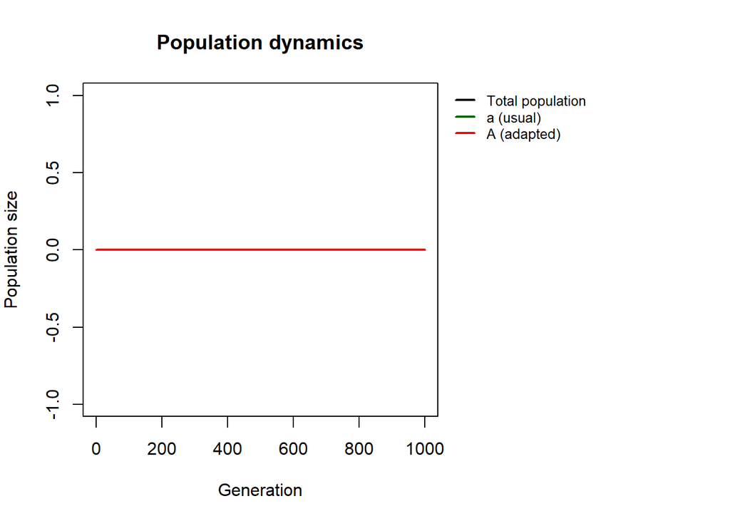

```r
# GENERATION NUMBERS FOR PLOT 1

# Create the generation numbers for the x-axis.
# There are 1001 population records, from generation 0 to 1000.
x_range <- 0:(nrow(output) - 1)

# Leave space on the right for the legend
par(mar = c(5, 4, 4, 14), xpd = NA)

# Total population
plot(
  x_range, rowSums(output),
  type = "l",
  col = "black",
  lwd = 2,
  ylim = c(0, max(rowSums(output))),
  xlab = "Generation",
  ylab = "Population size",
  main = "Population dynamics"
)

# Type a and type A
lines(x_range, output[, "a"], col = "darkgreen", lwd = 2)
lines(x_range, output[, "A"], col = "red", lwd = 2)

# Legend OUTSIDE the plot, on the right
legend(
  x = par("usr")[2] + xinch(0.05),
  y = par("usr")[4],
  xjust = 0, yjust = 1,
  cex = 0.8, seg.len = 1.5,
  legend = c("Total population", "a (usual)", "A (adapted)"),
  col = c("black", "darkgreen", "red"),
  lty = 1,
  lwd = 2,
  bty = "n",
  xpd = NA
)
```

```r
# Restore the standard margins
par(mar = c(5, 4, 4, 2), xpd = FALSE)
```

[figure not shown]

```r
# PLOTS 2: EFFECT OF MIGRATION

# Migration rates to compare
migration_rates <- c(1, 10^seq(-5, 0, by = 1))

# Repeat simulations to account for random variation
n_replicates <- 100

# Store the mean results for each migration rate
adapted_A <- numeric(length(migration_rates))
mig_a <- 1000 * migration_rates # Expected number of migrating turtles per generation
population_size <- numeric(length(migration_rates))
all_results <- vector("list", length(migration_rates))


for (j in seq_along(migration_rates)) {

  # Store the final results of repeated simulations
  results <- matrix(NA_real_, nrow = n_replicates, ncol = 3)

  for (rep in seq_len(n_replicates)) {

    sim <- simulate_pop(
      N_init_a = 0,
      N_init_A = 0,
      decay_rate = 0.1,
      sel_coeff = 0.2,
      mut_rate = 0.001,
      mig_rate = migration_rates[j],
      N_source_a = 1000,
      t_max = max_gen,
      carrying_capacity = 1000
    )

# Number of A and a turtles at the final generation
    results[rep, 1] <- sim[nrow(sim), "A"]

    results[rep, 2] <- sim[nrow(sim), "a"]

# Total population at the final generation
    results[rep, 3] <- sum(sim[nrow(sim), ])
  }

all_results[[j]] <- results

# Calculate the mean across replicate simulations
  adapted_A[j] <- mean(results[, 1])
  mig_a [j] <- mean(results[, 2])
  population_size[j] <- mean(results[, 3])
}

# PLOT 2: MIGRATION VS POPULATION TYPES AND TOTAL POPULATION

# Leave space on the right for the legend
par(mar = c(5, 4, 4, 13), xpd = NA)

# Install once in the Console if needed: install.packages("beeswarm")
if (!requireNamespace("beeswarm", quietly = TRUE)) {
  stop('Please install beeswarm first: install.packages("beeswarm")')
}

# Set up axes without drawing the mean lines yet
matplot(
  seq_along(migration_rates),
  cbind(adapted_A, mig_a, population_size),
  type = "n", xaxt = "n",
  xlim = c(0.5, length(migration_rates) + 0.5),
  ylim = range(c(0, unlist(all_results)), finite = TRUE),
  xlab = "Migration rate",
  ylab = "Number of turtles",
  main = "Effect of migration on population"
)

# Individual final-generation outcomes, behind the mean lines
swarm_colors <- c("red", "blue", "darkgreen")
for (k in 1:3) {
  beeswarm::beeswarm(
    lapply(all_results, function(x) x[, k]),
    at = seq_along(migration_rates),
    add = TRUE,
    pch = 16,
    cex = 0.45,
    col = adjustcolor(swarm_colors[k], alpha.f = 0.25),
    corral = "wrap",
    corralWidth = 0.6,
    xpd = FALSE
  )
}

# Original mean lines and symbols on top
matlines(
  seq_along(migration_rates),
  cbind(adapted_A, mig_a, population_size),
  type = "b",
  pch = c(19, 17, 15),
  col = c("red", "blue", "darkgreen"),
  lty = 1,
  lwd = 2
)
axis(
  side = 1,
  at = seq_along(migration_rates),
  labels = expression(0, 10^{-5}, 10^{-4}, 10^{-3},
                      10^{-2}, 10^{-1}, 10^{0})
)

legend(
  x = par("usr")[2] + xinch(0.05),
  y = par("usr")[4],
  xjust = 0, yjust = 1,
  legend = c("Adapted turtles (A)", "Migrating turtles (a)", "Total population (a + A)"),
  col = c("red", "blue", "darkgreen"),
  pch = c(19, 17, 15),
  lty = 1,
  lwd = 2,
  bty = "n",
  xpd = NA
)
```

```r
# Restore the standard plotting margins, leave space on the right for the legend, if needed.
par(mar = c(5, 4, 4, 2), xpd = FALSE)
```

## Implementation in a Shiny App

Shiny applications not supported in static R Markdown documents

# Questions & Answers

Can Migration help adapt to warming? How fast can they adapt? What is the maximum migration needed to stabilize the population? How many generation needed to reach the state population after migration happens? What factor that influences the migration rate and needed for added for next Model? Is immigration going to help the population adapt faster? In what condition can the population survive? Is immigration beneficial? How long can the local population sustain itself through immigration? How strong does the selection needs to be for the adapted ones to survive?

# Discussion

Our model suggests that immigration can improve the persistence and demographic recovery of a local sea-turtle population exposed to warming-related environmental stress. However, the highest immigration rate does not necessarily maximise the representation of the adapted type. Because all immigrants are assumed to be non-adapted, very high immigration rates can maintain a large local population while type *A* remains rare. The most interesting outcome is therefore the difference between demographic recovery and adaptation: a population can recover in terms of size without becoming dominated by the type that is better suited to the local environmental conditions. This is a theoretical result based on the assumptions of our model and should not be interpreted as a direct prediction for wild sea-turtle populations.

The initial motivation for our model was the increasing impact of rising temperatures on sea-turtle reproduction. Since temperature determines the sex of sea-turtle hatchlings, higher incubation temperatures lead to a greater proportion of female hatchlings. At the same time, increasing temperatures can reduce hatching success, meaning that fewer hatchlings successfully emerge from their nests. Together, these changes could affect the sex ratio of future populations and potentially reduce reproductive success, particularly if the number of males becomes insufficient for successful reproduction.

As a consequence, sea turtles may need to move more between different populations to find suitable reproductive partners. Furthermore, as temperatures continue to rise, they may not only need to change their migration routes to reach more suitable habitats, but may also need to adapt to the changing environmental conditions. We therefore wanted to investigate how migration, available resources and possible mutations leading to adaptation could interact and influence the persistence of a population under environmental warming.

An especially interesting aspect is how the combination of reduced hatching success and increasing feminisation could affect animal populations in which sex is determined by temperature. Even when reproduction is successful, a strongly female-biased sex ratio could potentially influence future reproductive events and the long-term viability of a population.

Our model examines whether adaptation can rescue a declining sea-turtle population and how immigration of non-adapted individuals influences population persistence and the spread of the adapted type through mutation and selection. It shows that immigration can support demographic recovery, but does not necessarily promote local adaptation. This distinction is important because maintaining population size alone may not be sufficient to ensure the long-term survival of a population under changing environmental conditions.

Future models could therefore include alternative migration routes, route-specific survival, more realistic temperature-dependent reproductive processes and changes in hatchling sex ratios. This would allow us to investigate more directly how changing temperatures, migration and adaptation interact, and whether these processes are sufficient to maintain viable sea-turtle populations under continued climate warming.

# References

Almpanidou, V., Markantonatou, V., & Mazaris, A. D. (2019). Thermal heterogeneity along the migration corridors of sea turtles: Implications for climate change ecology. *Journal of Experimental Marine Biology and Ecology, 520*, 151223. https://doi.org/10.1016/j.jembe.2019.151223

Duquesne, E., & Fournier, D. (2025). Climate change redefines sea turtle hotspots: Vessel strike risks and gaps in protected areas. *Science Advances, 11*(26), eadw4495. https://doi.org/10.1126/sciadv.adw4495

Fuentes, M. M. P. B., Santos, A. J. B., Abreu-Grobois, A., et al. (2024). Adaptation of sea turtles to climate warming: Will phenological responses be sufficient to counteract changes in reproductive output? *Global Change Biology, 30*(1), e16991. https://doi.org/10.1111/gcb.16991